# RProjectRedo

2025-01-17

The variables in this dataset are: education: Average years of education income: Average inome women: Percent of women prestige: Pineo-Porter prestige score census: Canada Census occupational code type: The type of job. Blue collar, white collar, and professional are the types.

```r
prestige = read.csv("C:/Users/katek/OneDrive - University of South Florida/Desktop/NCF/Fall 2024/Linear models/Prestige.txt", sep="")
```

Removing the “census” column, as it’s just an ID number. Also removing the “NA” values.

```r
prestige=na.omit(prestige)
prestigeclean=prestige[,-5]
```

Creating and interpreting a linear model:

```r
prmodel=lm(prestige~education+income+women+type,data=prestigeclean)
summary(prmodel)
```

```
##
## Call:
## lm(formula = prestige ~ education + income + women + type, data = prestigeclean)
##
## Residuals:
##      Min       1Q   Median       3Q      Max
## -14.7485  -4.4817   0.3119   5.2478  18.4978
##
## Coefficients:
##               Estimate Std. Error t value    Pr(>|t|)
## (Intercept) -0.8139032  5.3311558  -0.153    0.878994
## education    3.6623557  0.6458300   5.671 0.000000163 ***
## income       0.0010428  0.0002623   3.976    0.000139 ***
## women        0.0064434  0.0303781   0.212    0.832494
## typeprof     5.9051970  3.9377001   1.500    0.137127
## typewc      -2.9170720  2.6653961  -1.094    0.276626
## ---
## Signif. codes:  0 '***' 0.001 '**' 0.01 '*' 0.05 '.' 0.1 ' ' 1
##
## Residual standard error: 7.132 on 92 degrees of freedom
## Multiple R-squared:  0.8349, Adjusted R-squared:  0.826
## F-statistic: 93.07 on 5 and 92 DF,  p-value: < 0.00000000000000022
```

The equation for this model: prestige = -.81 + 3.66*education + .001*income + .0064*women + 5.91*typeprof - 2.92*typewc Education and income have a significant effect of prestige, since their P-values are less than .05. For every year of education, the career’s prestige increases by 3.66 on average, holding all other variables constant. For every dollar of income, the career’s prestige increases by .001 on average, holding all other variables constant.

Model with all variable interactions:

```r
prmodelint=lm(prestige~.^2,data=prestigeclean)
summary(prmodelint)
```

```
##
## Call:
## lm(formula = prestige ~ .^2, data = prestigeclean)
##
## Residuals:
##      Min       1Q   Median       3Q      Max
## -12.3782  -2.9830   0.5322   3.4854  13.1923
##
## Coefficients:
##                         Estimate    Std. Error t value   Pr(>|t|)
## (Intercept)          2.780719275  11.416708582   0.244     0.8082
## education            0.616904806   1.393864522   0.443     0.6592
## income               0.003545857   0.001391511   2.548     0.0127 *
## women               -0.011662615   0.205982957  -0.057     0.9550
## typeprof            41.357703574  21.462340671   1.927     0.0574 .
## typewc             -15.374796889  18.895817557  -0.814     0.4182
## education:income     0.000131472   0.000138490   0.949     0.3452
## education:women      0.017021480   0.028579160   0.596     0.5531
## education:typeprof   0.655378533   1.527933253   0.429     0.6691
## education:typewc     1.698039451   2.278450492   0.745     0.4582
## income:women         0.000002246   0.000019829   0.113     0.9101
## income:typeprof     -0.004838333   0.001011470  -4.783 0.00000739 ***
## income:typewc       -0.001001894   0.001881434  -0.533     0.5958
## women:typeprof      -0.258094435   0.157186927  -1.642     0.1044
## women:typewc        -0.014947263   0.138520078  -0.108     0.9143
## ---
## Signif. codes:  0 '***' 0.001 '**' 0.01 '*' 0.05 '.' 0.1 ' ' 1
##
## Residual standard error: 6.111 on 83 degrees of freedom
## Multiple R-squared:  0.8907, Adjusted R-squared:  0.8722
## F-statistic:  48.3 on 14 and 83 DF,  p-value: < 0.00000000000000022
```

Income:typeprof is a significant interaction, since its p-value is less than .05.

Creating model with the interaction term:

```r
printmodel=lm(prestige~education+income+women+type+income:type,data=prestigeclean)
```

Plotting the interaction:

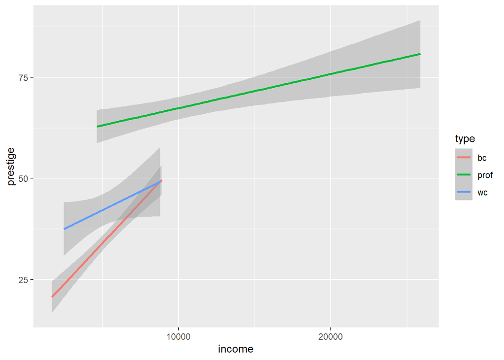

```r
ggplot(printmodel, aes(x=income, y=prestige, color=type)) + geom_smooth(method='lm')
```

```r
summary(printmodel)
```

```
##
## Call:
## lm(formula = prestige ~ education + income + women + type + income:type,
##     data = prestigeclean)
##
## Residuals:
##     Min      1Q  Median      3Q     Max
## -12.632  -4.518   1.057   3.850  18.171
##
## Coefficients:
##                    Estimate  Std. Error t value      Pr(>|t|)
## (Intercept)     -10.0769449   5.0099955  -2.011        0.0473 *
## education         2.8036054   0.5923347   4.733 0.00000817612 ***
## income            0.0038550   0.0005865   6.572 0.00000000315 ***
## women             0.0764837   0.0311733   2.453        0.0161 *
## typeprof         27.5496183   5.4096197   5.093 0.00000192674 ***
## typewc            3.4345704   5.3662992   0.640        0.5238
## income:typeprof  -0.0030085   0.0005754  -5.229 0.00000110088 ***
## income:typewc    -0.0010949   0.0008637  -1.268        0.2082
## ---
## Signif. codes:  0 '***' 0.001 '**' 0.01 '*' 0.05 '.' 0.1 ' ' 1
##
## Residual standard error: 6.284 on 90 degrees of freedom
## Multiple R-squared:  0.8746, Adjusted R-squared:  0.8649
## F-statistic:  89.7 on 7 and 90 DF,  p-value: < 0.00000000000000022
```

Performing an anova test between the model with and without the interaction term and interpreting the result:

```r
anova(prmodel, printmodel)
```

```
## Analysis of Variance Table
##
## Model 1: prestige ~ education + income + women + type
## Model 2: prestige ~ education + income + women + type + income:type
##   Res.Df    RSS Df Sum of Sq      F      Pr(>F)
## 1     92 4679.0
## 2     90 3553.6  2    1125.4 14.251 0.000004199 ***
## ---
## Signif. codes:  0 '***' 0.001 '**' 0.01 '*' 0.05 '.' 0.1 ' ' 1
```

The model with the interaction term has more significance than the one without.

Finding outliers:

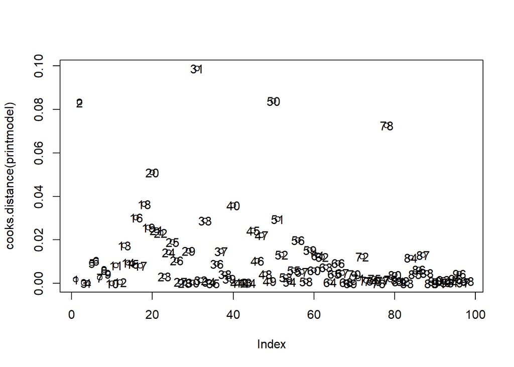

```r
plot(cooks.distance(printmodel))
text(cooks.distance(printmodel))
```

Removing outliers:

```r
prestigeout=prestigeclean[-c(2,31,50,78),]
```

Creating and interpreting the linear model:

```r
proutmodel=lm(prestige~education+income+women+type+income:type,data=prestigeout)
summary(proutmodel)
```

```
##
## Call:
## lm(formula = prestige ~ education + income + women + type + income:type,
##     data = prestigeout)
##
## Residuals:
##      Min       1Q   Median       3Q      Max
## -11.9007  -3.6289   0.5763   3.6160  10.8062
##
## Coefficients:
##                   Estimate Std. Error t value        Pr(>|t|)
## (Intercept)     -5.8159296  4.7233048  -1.231        0.221557
## education        2.1921369  0.5808135   3.774        0.000294 ***
## income           0.0040095  0.0005413   7.407 0.0000000000825 ***
## women            0.0567139  0.0294854   1.923        0.057731 .
## typeprof        31.1242980  4.9606164   6.274 0.0000000136891 ***
## typewc           5.6405564  5.1097706   1.104        0.272726
## income:typeprof -0.0030140  0.0005243  -5.748 0.0000001341412 ***
## income:typewc   -0.0010763  0.0008415  -1.279        0.204340
## ---
## Signif. codes:  0 '***' 0.001 '**' 0.01 '*' 0.05 '.' 0.1 ' ' 1
##
## Residual standard error: 5.693 on 86 degrees of freedom
## Multiple R-squared:  0.8982, Adjusted R-squared:   0.89
## F-statistic: 108.5 on 7 and 86 DF,  p-value: < 0.00000000000000022
```

The equation for this model: prestige = -5.82 + 2.19*education + .004*income + .057*women + 31.12*typeprof + 5.64*typewc - .003*income:typeprof - .0011*income:typewc Education, income, typeprof, and income:typeprof significantly effect prestige. For every year of education, the career’s prestige increases by 2.19 on average, holding all other variables constant. For every dollar of income, the prestige increases by .004 for blue collar jobs, .0029 for white collar jobs, and .001 for professional jobs. Additionally, the intercepts are -5.82, -.18, and 25.3 for blue collar, white collar, and professional jobs, respectively. Equation for professional jobs: (-5.82+31.12*typeprof) + 2.19*education + (.004*income-.003*income:typeprof) + .057*women = 25.3 + 2.19*education + .001*income + .057*women Equation for white collar jobs: (-5.82+5.64*typewc) + 2.19*education + (.004income-.0011*income:typewc) + .057*women = -.18 + 2.19*education + .0029*income + .057*women Equation for blue collar jobs: -5.82 + 2.19*education + .004*income + .057*women

Let’s compare models. For reference, the model with the interaction term is on top and the model on the bottom has the interaction term and no outliers.

```r
summary(printmodel)$fstatistic[1]
```

```
##    value
## 89.70428
```

```r
summary(proutmodel)$fstatistic[1]
```

```
##    value
## 108.4527
```

The F-statistic is much higher with the new model, so it’s even more likely at least 1 variable affects prestige.

```r
summary(printmodel)$r.squared
```

```
## [1] 0.8746396
```

```r
summary(proutmodel)$r.squared
```

```
## [1] 0.8982452
```

For the model with the outliers, the R-squared was 87.46%, meaning of the variance in prestige was explained by the other variables. Without them, 89.82% of the variance is explained by the other variables, making it a better model in that regard.

```r
sigma(printmodel)
```

```
## [1] 6.283644
```

```r
sigma(proutmodel)
```

```
## [1] 5.692513
```

Finding and interpreting confidence intervals:

```r
confint(proutmodel)[1,]
```

```
##     2.5 %    97.5 %
## -15.20555   3.57369
```

I am 95% confident that for careers with 0 years of education, 0% women, and $0 income, the prestige will be between 0 and 3.57. For this interpretation, I cut it off at 0, because a negative prestige rating doesn’t exist.

```r
confint(proutmodel)[2,]
```

```
##    2.5 %   97.5 %
## 1.037518 3.346756
```

```r
confint(proutmodel)[3,]
```

```
##       2.5 %      97.5 %
## 0.002933334 0.005085641
```

```r
confint(proutmodel)[4,]
```

```
##        2.5 %       97.5 %
## -0.001901116  0.115328855
```

I am 95% confident that for every year of education, the prestige increases by between 1.04 and 3.35 points on average. I am 95% confident that for every dollar of income, the prestige increases by between .0029 and .0051 points on average. I am 95% confident that the slope of the relationship between the percent of women and prestige is between -.0019 and .12 points on average.

Scaling the numerical variables:

```r
prestigescaled=data.frame(scale(prestigeout[,1:4]))
prestigescaled$type=prestigeout$type
```

With the model using the scaled data, I can see what variable affects prestige the most.

```r
prscmodel=lm(prestige~education+income+women+type+income:type,data=prestigescaled)
summary(prscmodel)
```

```
##
## Call:
## lm(formula = prestige ~ education + income + women + type + income:type,
##     data = prestigescaled)
##
## Residuals:
##      Min       1Q   Median       3Q      Max
## -0.69349 -0.21147  0.03358  0.21072  0.62971
##
## Coefficients:
##                 Estimate Std. Error t value        Pr(>|t|)
## (Intercept)     -0.02077    0.09437  -0.220        0.826304
## education        0.35607    0.09434   3.774        0.000294 ***
## income           0.89254    0.12051   7.407 0.0000000000825 ***
## women            0.10277    0.05343   1.923        0.057731 .
## typeprof         0.62493    0.19088   3.274        0.001529 **
## typewc          -0.09583    0.14505  -0.661        0.510608
## income:typeprof -0.67095    0.11672  -5.748 0.0000001341412 ***
## income:typewc   -0.23960    0.18733  -1.279        0.204340
## ---
## Signif. codes:  0 '***' 0.001 '**' 0.01 '*' 0.05 '.' 0.1 ' ' 1
##
## Residual standard error: 0.3317 on 86 degrees of freedom
## Multiple R-squared:  0.8982, Adjusted R-squared:   0.89
## F-statistic: 108.5 on 7 and 86 DF,  p-value: < 0.00000000000000022
```

The equation for this model: prestige = -.021 + .36*education + .89*income + .1*women + .62*typeprof - .096*typewc - .67*income:typeprof - .24*income:typewc Income has the strongest effect on prestige, because the absolute value of its estimate is the highest. Listing the variables from strongest significant effect to weakest significant effect on prestige gives us: income, income:typeprof, typeprof, then education. Surprisingly, education doesn’t matter as much as the type of job or income when it comes to the prestige score.